# Rolling Sales Manhattan-visualizations - Website

## Data Load

Data is loaded from a local copy of Rolling Sales data for Manhattan sourced at “analysis/data/rollingsales_manhattan.csv”. This is done by calling the load script “analysis/Load.R”. The structure of the loaded data set is shown below.

```r
source("analysis/Load.R",echo = TRUE)
```

```
##
## > readURL <- "analysis/data/rollingsales_manhattan.csv"
##
## > bk <- read.csv(readURL, skip = 4, header = TRUE)
##
## > str(bk)
## 'data.frame':    23412 obs. of  21 variables:
##  $ BOROUGH                       : int  1 1 1 1 1 1 1 1 1 1 ...
##  $ NEIGHBORHOOD                  : Factor w/ 39 levels "ALPHABET CITY            ",..: 1 1 1 1 1 1 1 1 1 1 ...
##  $ BUILDING.CLASS.CATEGORY       : Factor w/ 42 levels "01  ONE FAMILY DWELLINGS                    ",..: 3 3 4 5 5 5 5 5 5 5 ...
##  $ TAX.CLASS.AT.PRESENT          : Factor w/ 8 levels "1","1A","1C",..: 1 1 3 6 6 4 4 4 4 4 ...
##  $ BLOCK                         : int  376 377 399 373 373 377 377 385 387 387 ...
##  $ LOT                           : int  24 66 1101 16 17 2 2 2 119 119 ...
##  $ EASE.MENT                     : logi  NA NA NA NA NA NA ...
##  $ BUILDING.CLASS.AT.PRESENT     : Factor w/ 123 levels "A1","A4","A5",..: 10 10 92 11 11 17 17 17 17 17 ...
##  $ ADDRESS                       : Factor w/ 12053 levels "1 5TH AVENUE, 11F/G                      ",..: 5794 5235 5071 7252 7266 738 738 4096 10862 10862 ...
##  $ APARTMENT.NUMBER              : Factor w/ 2758 levels "-           ",..: 2 2 1 2 2 2 2 2 2 2 ...
##  $ ZIP.CODE                      : int  10009 10009 10009 10009 10009 10009 10009 10009 10009 10009 ...
##  $ RESIDENTIAL.UNITS             : int  3 3 1 10 10 22 22 12 22 22 ...
##  $ COMMERCIAL.UNITS              : int  0 0 0 0 0 3 3 4 2 2 ...
##  $ TOTAL.UNITS                   : int  3 3 1 10 10 25 25 16 24 24 ...
##  $ LAND.SQUARE.FEET              : int  2059 2381 0 2204 2204 4510 4510 4186 3445 3445 ...
##  $ GROSS.SQUARE.FEET             : int  3696 3084 0 8625 8625 19830 19830 10588 13546 13546 ...
##  $ YEAR.BUILT                    : int  1900 1899 1955 1899 1900 1900 1900 1900 1920 1920 ...
##  $ TAX.CLASS.AT.TIME.OF.SALE     : int  1 1 1 2 2 2 2 2 2 2 ...
##  $ BUILDING.CLASS.AT.TIME.OF.SALE: Factor w/ 123 levels "A1","A4","A5",..: 10 10 92 11 11 17 17 17 17 17 ...
##  $ SALE.PRICE                    : Factor w/ 6619 levels " $-   "," $1 ",..: 2989 2312 5042 2357 1 1579 1 1 1160 1 ...
##  $ SALE.DATE                     : Factor w/ 339 levels "1/1/2016","1/11/2016",..: 40 236 227 65 65 311 311 143 115 115 ...
```

## Data Conversion and Cleanup

```r
source("analysis/DataConversion.R",echo = TRUE)
```

```
##
## > bk$SALE.PRICE.N <- as.numeric(gsub("[^[:digit:]]",
## +     "", bk$SALE.PRICE))
##
## > count(is.na(bk$SALE.PRICE.N))
##       x  freq
## 1 FALSE 18611
## 2  TRUE  4801
##
## > names(bk) <- tolower(names(bk))
##
## > bk$gross.sqft <- as.numeric(gsub("[^[:digit:]]", "",
## +     bk$gross.square.feet))
##
## > bk$land.sqft <- as.numeric(gsub("[^[:digit:]]", "",
## +     bk$land.square.feet))
##
## > bk$sale.date <- as.Date(bk$sale.date, "%m/%d/%Y")
##
## > bk$year.built <- as.numeric((bk$year.built))
##
## > str(bk)
## 'data.frame':    23412 obs. of  24 variables:
##  $ borough                       : int  1 1 1 1 1 1 1 1 1 1 ...
##  $ neighborhood                  : Factor w/ 39 levels "ALPHABET CITY            ",..: 1 1 1 1 1 1 1 1 1 1 ...
##  $ building.class.category       : Factor w/ 42 levels "01  ONE FAMILY DWELLINGS                    ",..: 3 3 4 5 5 5 5 5 5 5 ...
##  $ tax.class.at.present          : Factor w/ 8 levels "1","1A","1C",..: 1 1 3 6 6 4 4 4 4 4 ...
##  $ block                         : int  376 377 399 373 373 377 377 385 387 387 ...
##  $ lot                           : int  24 66 1101 16 17 2 2 2 119 119 ...
##  $ ease.ment                     : logi  NA NA NA NA NA NA ...
##  $ building.class.at.present     : Factor w/ 123 levels "A1","A4","A5",..: 10 10 92 11 11 17 17 17 17 17 ...
##  $ address                       : Factor w/ 12053 levels "1 5TH AVENUE, 11F/G                      ",..: 5794 5235 5071 7252 7266 738 738 4096 10862 10862 ...
##  $ apartment.number              : Factor w/ 2758 levels "-           ",..: 2 2 1 2 2 2 2 2 2 2 ...
##  $ zip.code                      : int  10009 10009 10009 10009 10009 10009 10009 10009 10009 10009 ...
##  $ residential.units             : int  3 3 1 10 10 22 22 12 22 22 ...
##  $ commercial.units              : int  0 0 0 0 0 3 3 4 2 2 ...
##  $ total.units                   : int  3 3 1 10 10 25 25 16 24 24 ...
##  $ land.square.feet              : int  2059 2381 0 2204 2204 4510 4510 4186 3445 3445 ...
##  $ gross.square.feet             : int  3696 3084 0 8625 8625 19830 19830 10588 13546 13546 ...
##  $ year.built                    : num  1900 1899 1955 1899 1900 ...
##  $ tax.class.at.time.of.sale     : int  1 1 1 2 2 2 2 2 2 2 ...
##  $ building.class.at.time.of.sale: Factor w/ 123 levels "A1","A4","A5",..: 10 10 92 11 11 17 17 17 17 17 ...
##  $ sale.price                    : Factor w/ 6619 levels " $-   "," $1 ",..: 2989 2312 5042 2357 1 1579 1 1 1160 1 ...
##  $ sale.date                     : Date, format: "2015-10-22" "2015-06-24" ...
##  $ sale.price.n                  : num  3775000 2900000 6995000 20000000 NA ...
##  $ gross.sqft                    : num  3696 3084 0 8625 8625 ...
##  $ land.sqft                     : num  2059 2381 0 2204 2204 ...
```

## Sales Price Data

We are now able to see some trends in the data. Using the script “analysis/Analysis1.R” we can generate a histogram for the sales price data.

```r
source("analysis/Analysis1.R",echo = TRUE)
```

```
##
## > attach(bk)
##
## > hist(sale.price.n)
```

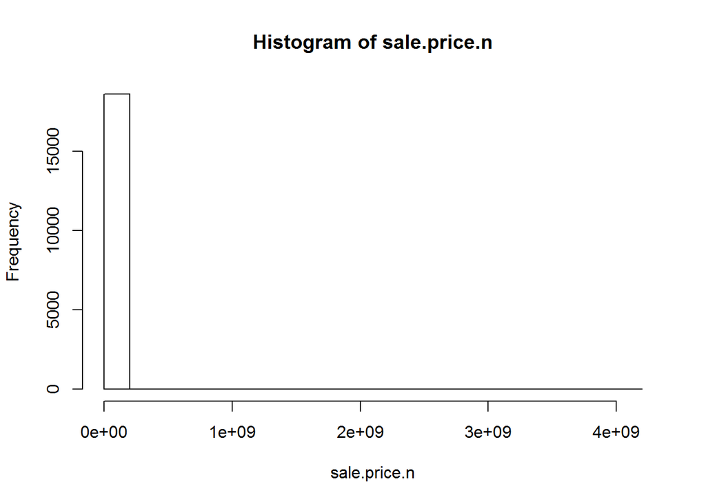

Using the script “analysis/Analysis2.R” we can generate a histogram for the sales price data for all sales prices greater than $0. This plot looks the same as the prior one.

```r
source("analysis/Analysis2.R",echo = TRUE)
```

```
##
## > hist(sale.price.n[sale.price.n > 0])
```

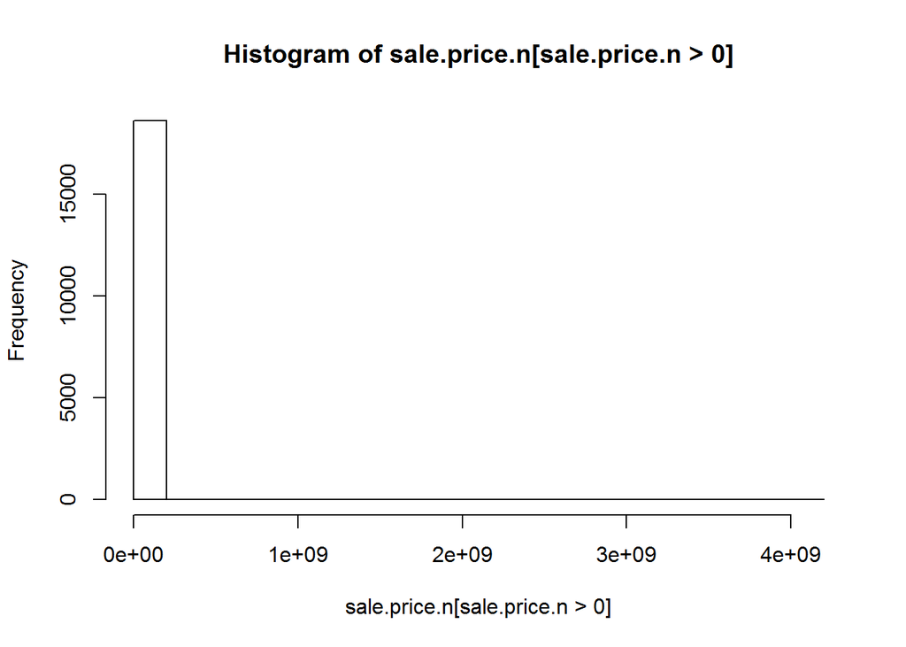

Using the script “analysis/Analysis3.R” we can generate a summary for the sale price data.

```r
source("analysis/Analysis3.R",echo = TRUE)
```

```
##
## > summary(sale.price.n)
##      Min.   1st Qu.    Median      Mean   3rd Qu.      Max.      NA's
## 1.000e+00 3.950e+05 8.550e+05 3.456e+06 2.000e+06 4.111e+09      4801
```

## Conversion of Sales Price Data to Log Scale

The prior plots revealed that the data was heavily concentrated therefore, we took the log of the same data. Using the script “analysis/Analysis4.R” we can generate a histogram for the sales price data on a log scale (base 10). We see that the data appears to not have a strong log form, but tend to move in a positive diration aside from outliers.

```r
source("analysis/Analysis4.R")
```

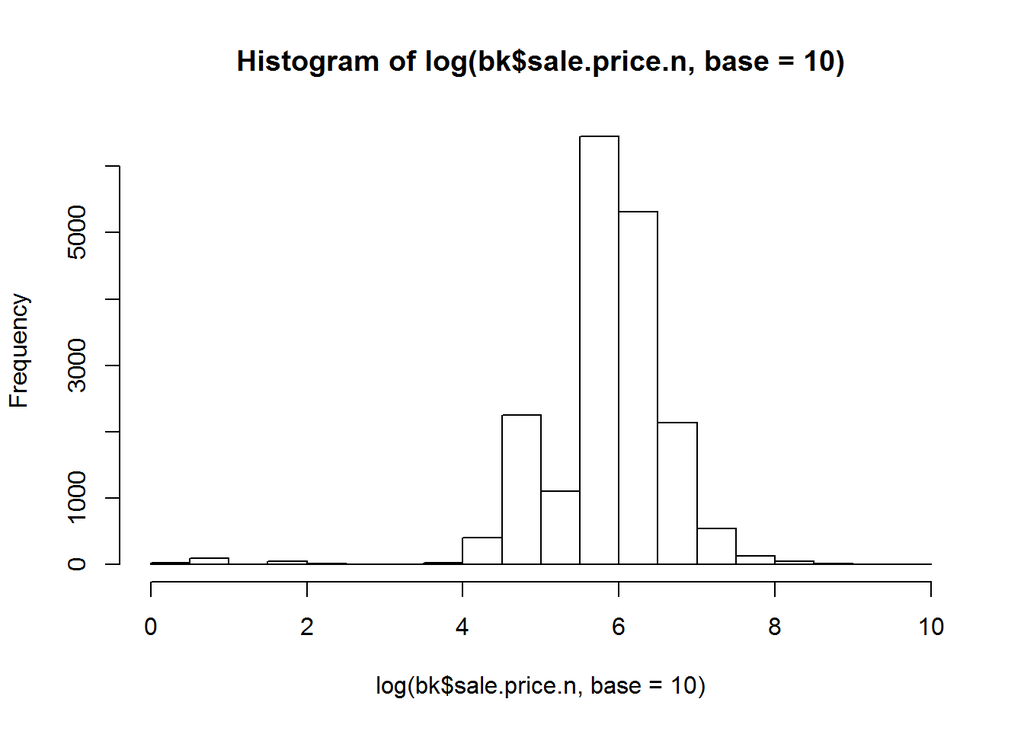

```r
source("analysis/Analysis5.R", echo = TRUE)
```

```
##
## > hist(sale.price.n[sale.price.n < 1e+08])
```

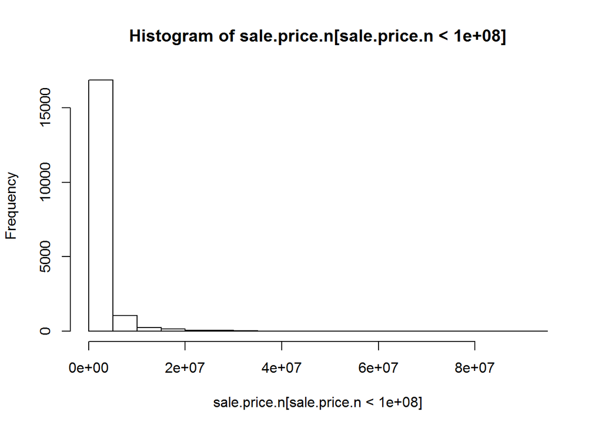

But that still shows one big cluster. Using the script “analysis/Analysis6.R” we can see though that there are no zero’s in our set.

```r
source("analysis/Analysis6.R",echo = TRUE)
```

```
##
## > count(sale.price.n == 0)
##       x  freq
## 1 FALSE 18611
## 2    NA  4801
##
## > detach(bk)
```

## Further Analysis

Further Analysis can now be done. Using the script “analysis/Analysis7.R” we can get only records from the sales price data that have non-zero values. A summary of the data set is shown below.

```r
source("analysis/Analysis7.R", echo = TRUE)
```

```
##
## > bk.sale <- bk[bk$sale.price.n != 0, ]
##
## > summary(bk.sale)
##     borough                        neighborhood
##  Min.   :1      MIDTOWN WEST             :3662
##  1st Qu.:1      UPPER EAST SIDE (59-79)  :1895
##  Median :1      UPPER EAST SIDE (79-96)  :1467
##  Mean   :1      UPPER WEST SIDE (59-79)  :1341
##  3rd Qu.:1      MIDTOWN EAST             :1159
##  Max.   :1      (Other)                  :9087
##  NA's   :4801   NA's                     :4801
##                                  building.class.category
##  13  CONDOS - ELEVATOR APARTMENTS            :6099
##  10  COOPS - ELEVATOR APARTMENTS             :5860
##  45  CONDO HOTELS                            :2279
##  17  CONDO COOPS                             :1144
##  09  COOPS - WALKUP APARTMENTS               : 731
##  (Other)                                     :2498
##  NA's                                        :4801
##  tax.class.at.present     block           lot         ease.ment
##  2      :14023        Min.   :   7   Min.   :   1.0   Mode:logical
##  4      : 3533        1st Qu.: 874   1st Qu.:  35.0   NA's:23412
##  2C     :  534        Median :1076   Median :1008.0
##  1      :  242        Mean   :1116   Mean   : 793.8
##  2B     :  169        3rd Qu.:1414   3rd Qu.:1302.0
##  (Other):  110        Max.   :2250   Max.   :9117.0
##  NA's   : 4801        NA's   :4801   NA's   :4801
##  building.class.at.present
##  R4     :6100
##  D4     :5633
##  RH     :2279
##  R9     :1144
##  C6     : 723
##  (Other):2732
##  NA's   :4801
##                                       address          apartment.number
##  1335 AVENUE OF THE AMERIC                : 1770               :9675
##  102 WEST 57TH STREET                     :  610   HU2         :1449
##  1335 AVENUE OF THE AMER                  :  391   TIMES       : 712
```

[output cut: 29 more lines]

```
##   $45,000    :  217   Min.   :2015-05-01   Min.   :1.000e+00
##   $10        :   97   1st Qu.:2015-07-23   1st Qu.:3.950e+05
##   $850,000   :   84   Median :2015-10-08   Median :8.550e+05
##   $650,000   :   80   Mean   :2015-10-14   Mean   :3.456e+06
##   $1,500,000 :   76   3rd Qu.:2016-01-04   3rd Qu.:2.000e+06
##  (Other)     :18057   Max.   :2016-04-29   Max.   :4.111e+09
##  NA's        : 4801   NA's   :4801         NA's   :4801
##    gross.sqft        land.sqft
##  Min.   :      0   Min.   :      0.0
##  1st Qu.:      0   1st Qu.:      0.0
##  Median :      0   Median :      0.0
##  Mean   :   6841   Mean   :    840.6
##  3rd Qu.:      0   3rd Qu.:      0.0
##  Max.   :8942176   Max.   :2675000.0
##  NA's   :4801      NA's   :4801
```

Using the script “analysis/Analysis8.R” we can plot Sales Prices versus Gross Square Footage.

```r
source("analysis/Analysis8.R", echo = TRUE)
```

```
##
## > plot(bk.sale$gross.sqft, bk.sale$sale.price.n)
```

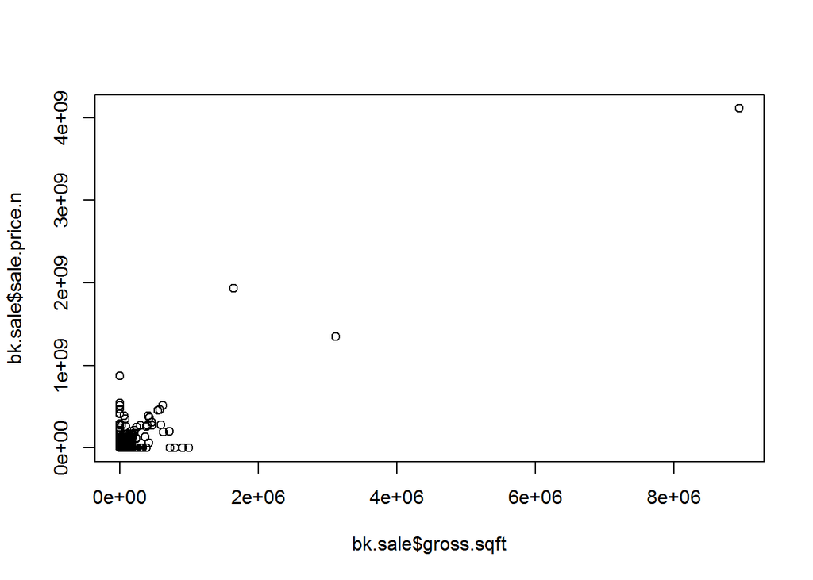

Using the script “analysis/Analysis9.R” we can plot Sales Prices versus Gross Square Footage on a log scale.

```r
source("analysis/Analysis9.R", echo = TRUE)
```

```
##
## > plot(log(bk.sale$gross.sqft, base = 10), log(bk.sale$sale.price.n,
## +     base = 10))
```

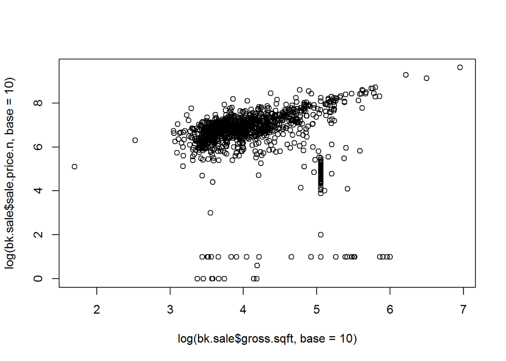

Using the script “analysis/Analysis10.R” we can again plot Sales Prices versus Gross Square Footage but filter for homes which have family in the class type to receive a much more centered looking dataset. We can see that the variances across square footage have now become very constant and the trend looks somewhat linear. The only troubling item in the graph now is the outliers below 5 on the y-axis.

```r
source("analysis/Analysis10.R", echo = TRUE)
```

```
##
## > bk.homes <- bk.sale[which(grepl("FAMILY", bk.sale$building.class.category)),
## +     ]
##
## > dim(bk.homes)
## [1] 242  24
##
## > plot(log(bk.homes$gross.sqft, base = 10), log(bk.homes$sale.price.n,
## +     base = 10))
```

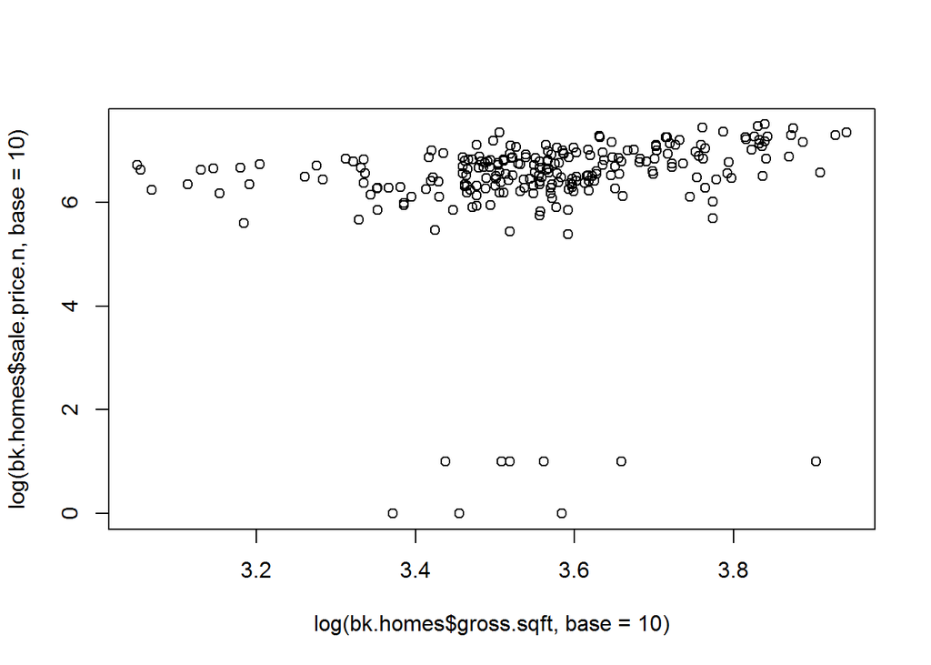

```r
source("analysis/Analysis11.R", echo = TRUE)
```

```
##
## > summary(bk.homes[which(bk.homes$sale.price.n < 1e+05),
## +     ])
##     borough                     neighborhood
##  Min.   :1   UPPER WEST SIDE (96-116) :3
##  1st Qu.:1   HARLEM-EAST              :2
##  Median :1   UPPER EAST SIDE (79-96)  :2
##  Mean   :1   GREENWICH VILLAGE-WEST   :1
##  3rd Qu.:1   KIPS BAY                 :1
##  Max.   :1   MIDTOWN EAST             :1
##              (Other)                  :1
##                                  building.class.category
##  03  THREE FAMILY DWELLINGS                  :6
##  02  TWO FAMILY DWELLINGS                    :3
##  01  ONE FAMILY DWELLINGS                    :2
##  04  TAX CLASS 1 CONDOS                      :0
##  07  RENTALS - WALKUP APARTMENTS             :0
##  08  RENTALS - ELEVATOR APARTMENTS           :0
##  (Other)                                     :0
##  tax.class.at.present     block           lot         ease.ment
##  1      :11           Min.   : 593   Min.   : 13.00   Mode:logical
##  1A     : 0           1st Qu.:1236   1st Qu.: 38.00   NA's:11
##  1C     : 0           Median :1520   Median : 42.00
##  2      : 0           Mean   :1474   Mean   : 57.55
##  2A     : 0           3rd Qu.:1849   3rd Qu.: 62.00
##  2B     : 0           Max.   :1891   Max.   :150.00
##  (Other): 0
##  building.class.at.present                                      address
##  C0     :6                 333 RIVERSIDE DRIVE                      :3
##  B1     :2                 118 E 83RD                               :1
##  A9     :1                 128 EAST 92ND   STREET                   :1
##  B3     :1                 129 WEST 78TH STREET                     :1
##  S1     :1                 22 CHRISTOPHER STREET                    :1
##  A1     :0                 234 EAST 49TH   STREET                   :1
##  (Other):0                 (Other)                                  :3
##      apartment.number    zip.code     residential.units commercial.units
##              :11      Min.   :10003   Min.   :1.000     Min.   :0.00000
##  -           : 0      1st Qu.:10020   1st Qu.:2.000     1st Qu.:0.00000
##  (-)         : 0      Median :10025   Median :3.000     Median :0.00000
##  1           : 0      Mean   :10033   Mean   :2.364     Mean   :0.09091
```

[output cut: 20 more lines]

```
##   $10        :8    Min.   :2015-05-07   Min.   : 1.000   Min.   :2352
##   $1         :3    1st Qu.:2015-05-27   1st Qu.: 5.500   1st Qu.:3038
##   $-         :0    Median :2015-06-11   Median :10.000   Median :3645
##   $1,000     :0    Mean   :2015-07-13   Mean   : 7.545   Mean   :4594
##   $1,000,000 :0    3rd Qu.:2015-07-26   3rd Qu.:10.000   3rd Qu.:6284
##   $1,000,391 :0    Max.   :2015-12-14   Max.   :10.000   Max.   :8007
##  (Other)     :0
##    land.sqft
##  Min.   :1235
##  1st Qu.:1572
##  Median :1840
##  Mean   :1876
##  3rd Qu.:2292
##  Max.   :2554
##
```